# Lab 3: Estadistica Descriptiva 2

Maximiliano Garnier Villarreal

# 1 Estadistica descriptiva

Vamos a usar los datos de `airquality`.

```r
airq = airquality %>%
  as_tibble()
airq
```

| Ozone | Solar.R | Wind | Temp | Month | Day |
| --- | --- | --- | --- | --- | --- |
| 41 | 190 | 7.4 | 67 | 5 | 1 |
| 36 | 118 | 8.0 | 72 | 5 | 2 |
| 12 | 149 | 12.6 | 74 | 5 | 3 |
| 18 | 313 | 11.5 | 62 | 5 | 4 |
| NA | NA | 14.3 | 56 | 5 | 5 |
| 28 | NA | 14.9 | 66 | 5 | 6 |
| 23 | 299 | 8.6 | 65 | 5 | 7 |
| 19 | 99 | 13.8 | 59 | 5 | 8 |
| 8 | 19 | 20.1 | 61 | 5 | 9 |
| NA | 194 | 8.6 | 69 | 5 | 10 |

[output cut: 143 more lines]

## 1.1 Bivariable

Las funciones covarianza (`cov`) y correlacion (`cor`) pueden actuar sobre vectores o sobre DataFrames. En estos ultimos el resultado va a ser una matriz de covarianza o correlacion, en su mayoria se requiere que el DataFrame sea numerico, sin columnas de texto o factores.

```r
x = airq$Solar.R
y = airq$Temp

cov(x,y,use = 'pairwise.complete.obs') # covarianza
```

```
## [1] 229.1598
```

```r
cor(x,y,method = "pearson",
    use = 'pairwise.complete.obs') # coeficiente de correlacion de Pearson
```

```
## [1] 0.2758403
```

```r
cov(airq, use = 'pairwise.complete.obs') # matriz de varianza-covarianza
```

```
##               Ozone     Solar.R        Wind       Temp      Month          Day
## Ozone   1088.200525 1056.583456 -70.9385307 218.521214  8.0089205   -3.8175412
## Solar.R 1056.583456 8110.519414 -17.9459707 229.159754 -9.5222485 -119.0259802
## Wind     -70.938531  -17.945971  12.4115385 -15.272136 -0.8897532    0.8488519
## Temp     218.521214  229.159754 -15.2721362  89.591331  5.6439628  -10.9574303
## Month      8.008921   -9.522248  -0.8897532   5.643963  2.0065359   -0.0999742
## Day       -3.817541 -119.025980   0.8488519 -10.957430 -0.0999742   78.5797214
```

```r
cor(airq, use = 'pairwise.complete.obs') # matriz de correlacion de Pearson
```

```
##               Ozone     Solar.R        Wind       Temp        Month
## Ozone    1.00000000  0.34834169 -0.60154653  0.6983603  0.164519314
## Solar.R  0.34834169  1.00000000 -0.05679167  0.2758403 -0.075300764
## Wind    -0.60154653 -0.05679167  1.00000000 -0.4579879 -0.178292579
## Temp     0.69836034  0.27584027 -0.45798788  1.0000000  0.420947252
## Month    0.16451931 -0.07530076 -0.17829258  0.4209473  1.000000000
## Day     -0.01322565 -0.15027498  0.02718090 -0.1305932 -0.007961763
##                  Day
## Ozone   -0.013225647
## Solar.R -0.150274979
## Wind     0.027180903
## Temp    -0.130593175
## Month   -0.007961763
## Day      1.000000000
```

```r
correlation(airq, method = 'pearson')
```

|  | Parameter1 | Parameter2 | r | CI | CI_low | CI_high | t | df_error | p | Method | n_Obs |
| --- | --- | --- | --- | --- | --- | --- | --- | --- | --- | --- | --- |
| 1 | Ozone | Solar.R | 0.348341693 | 0.95 | 0.17319400 | 0.50213196 | 3.87979481 | 109 | 1.972419e-03 | Pearson correlation | 111 |
| 2 | Ozone | Wind | -0.601546530 | 0.95 | -0.70639179 | -0.47087128 | -8.04012988 | 114 | 1.298076e-11 | Pearson correlation | 116 |
| 3 | Ozone | Temp | 0.698360342 | 0.95 | 0.59133397 | 0.78121106 | 10.41772418 | 114 | 4.397845e-17 | Pearson correlation | 116 |
| 4 | Ozone | Month | 0.164519314 | 0.95 | -0.01834762 | 0.33673567 | 1.78085173 | 114 | 5.617870e-01 | Pearson correlation | 116 |
| 5 | Ozone | Day | -0.013225647 | 0.95 | -0.19507188 | 0.16949967 | -0.14122361 | 114 | 1.000000e+00 | Pearson correlation | 116 |
| 6 | Solar.R | Wind | -0.056791666 | 0.95 | -0.21723589 | 0.10664055 | -0.68260167 | 144 | 1.000000e+00 | Pearson correlation | 146 |
| 7 | Solar.R | Temp | 0.275840271 | 0.95 | 0.11871132 | 0.41949133 | 3.44368627 | 144 | 7.517729e-03 | Pearson correlation | 146 |
| 8 | Solar.R | Month | -0.075300764 | 0.95 | -0.23487603 | 0.08822685 | -0.90618194 | 144 | 1.000000e+00 | Pearson correlation | 146 |
| 9 | Solar.R | Day | -0.150274979 | 0.95 | -0.30527111 | 0.01247802 | -1.82401281 | 144 | 5.617870e-01 | Pearson correlation | 146 |
| 10 | Wind | Temp | -0.457987879 | 0.95 | -0.57488741 | -0.32276602 | -6.33083510 | 151 | 3.434076e-08 | Pearson correlation | 153 |

[output cut: 5 more lines]

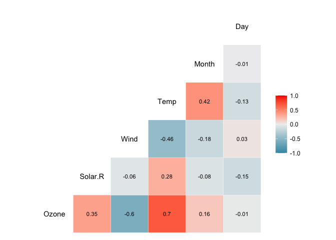

```r
# grafico estatico de coeficientes de correlacion

GGally::ggcorr(airq, label = T,
               label_round = 2,
               label_size = 3,
               method = c('pairwise.complete.obs','pearson'))
```

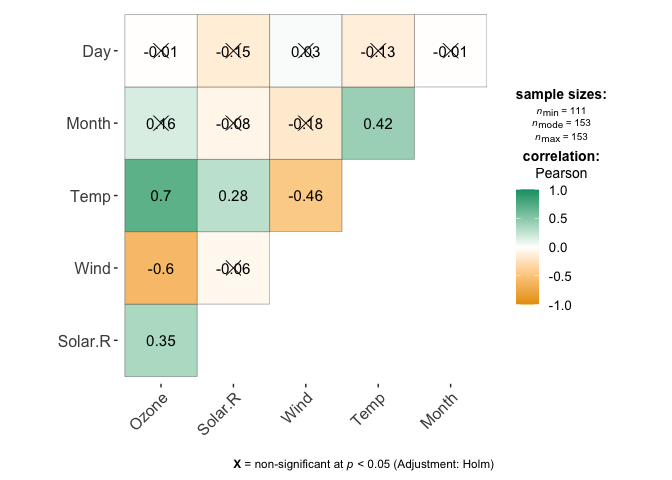

```r
ggstatsplot::ggcorrmat(airq)
```

El siguiente codigo genera un grafico interactivo de la matriz de correlacion (Solo se despliega en formato HTML).

```r
hchart(cor(airq,use = 'pairwise.complete.obs')) # grafico interactivo de coeficientes de correlacion
```

[interactive chart not shown]

## 1.2 Regresion

Para presentar caracteristicas de los modelos de forma mas estetica y ordenada se pueden usar las funciones `tidy` y `glance` del paquete *broom*, o `model_parameter` y `model_performance` de los paquetes *parameters* y *performance*. `tidy` y `model_parameter` genera la tabla resumen de los coeficientes y sus estadisticas, mientras que `glance` y `model_performance` genera una tabla con medidas de ajuste, incluyendo el $R^2$.

### 1.2.1 Lineal

$y \thicksim \hat{b}_0 + x\hat{b}_1 + \epsilon$

```r
mod1 = lm(Temp ~ Solar.R, data = airq) # modelo de regresion lineal

mod1 %>% tidy()
```

| term | estimate | std.error | statistic | p.value |
| --- | --- | --- | --- | --- |
| (Intercept) | 72.86301176 | 1.693950864 | 43.013651 | 4.541566e-84 |
| Solar.R | 0.02825463 | 0.008204764 | 3.443686 | 7.517729e-04 |

```r
mod1 %>% glance()
```

| r.squared | adj.r.squared | sigma | statistic | p.value | df | logLik | AIC | BIC | deviance | df.residual | nobs |
| --- | --- | --- | --- | --- | --- | --- | --- | --- | --- | --- | --- |
| 0.07608786 | 0.0696718 | 8.897632 | 11.85898 | 0.0007517729 | 1 | -525.2827 | 1056.565 | 1065.516 | 11400.17 | 144 | 146 |

```r
mod1 %>% model_parameters()
```

|  | Parameter | Coefficient | SE | CI | CI_low | CI_high | t | df_error | p |
| --- | --- | --- | --- | --- | --- | --- | --- | --- | --- |
| 1 | (Intercept) | 72.86301176 | 1.693950864 | 0.95 | 69.5147907 | 76.21123280 | 43.013651 | 144 | 4.541566e-84 |
| 2 | Solar.R | 0.02825463 | 0.008204764 | 0.95 | 0.0120373 | 0.04447197 | 3.443686 | 144 | 7.517729e-04 |

```r
mod1 %>% model_performance()
```

|  | AIC | BIC | R2 | R2_adjusted | RMSE | Sigma |
| --- | --- | --- | --- | --- | --- | --- |
| 1 | 1056.565 | 1065.516 | 0.07608786 | 0.0696718 | 8.836479 | 8.897632 |

```r
sjstats::cv(mod1) # cv
```

```
## [1] 0.1131193
```

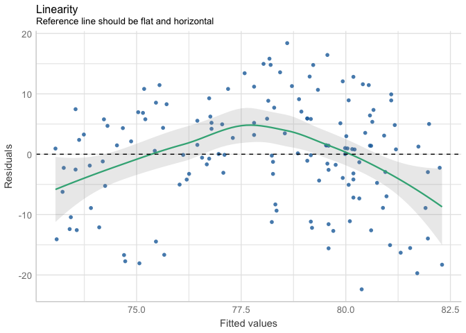

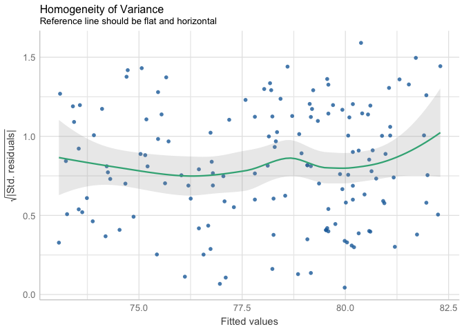

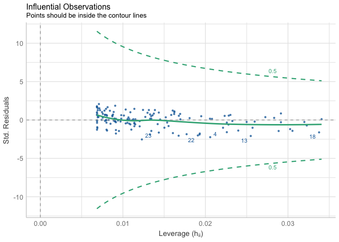

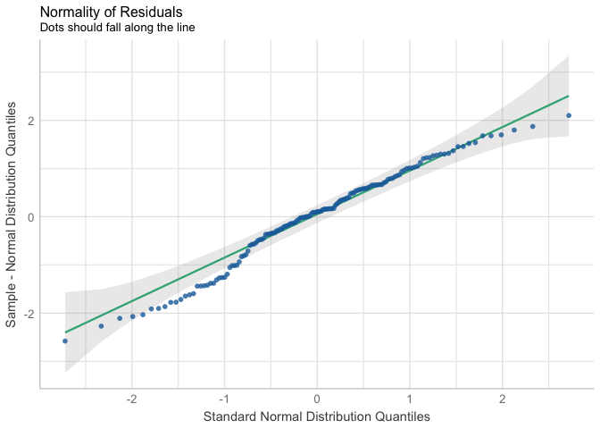

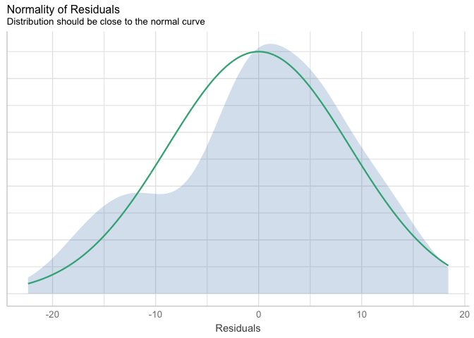

```r
# graficos diagnostico
# plot(mod1) # graficos diagnostico
check_model(mod1,panel=F)
```

### 1.2.2 Cuadratica

$y \thicksim \hat{b}_0 + x\hat{b}_1 + x^2\hat{b}_2 + \epsilon$

```r
mod2 = lm(Temp ~ Solar.R + I(Solar.R^2), data = airq) # modelo de regresion cuadratica

mod2 %>% tidy()
```

| term | estimate | std.error | statistic | p.value |
| --- | --- | --- | --- | --- |
| (Intercept) | 64.2677293059 | 2.397337e+00 | 26.807969 | 1.236156e-57 |
| Solar.R | 0.1758133953 | 3.189690e-02 | 5.511928 | 1.608610e-07 |
| I(Solar.R^2) | -0.0004420017 | 9.275735e-05 | -4.765139 | 4.588509e-06 |

```r
mod2 %>% glance()
```

| r.squared | adj.r.squared | sigma | statistic | p.value | df | logLik | AIC | BIC | deviance | df.residual | nobs |
| --- | --- | --- | --- | --- | --- | --- | --- | --- | --- | --- | --- |
| 0.2026903 | 0.1915391 | 8.294417 | 18.17657 | 9.254073e-08 | 2 | -514.5245 | 1037.049 | 1048.983 | 9838.02 | 143 | 146 |

```r
mod2 %>% model_parameters()
```

|  | Parameter | Coefficient | SE | CI | CI_low | CI_high | t | df_error | p |
| --- | --- | --- | --- | --- | --- | --- | --- | --- | --- |
| 1 | (Intercept) | 64.2677293059 | 2.397337e+00 | 0.95 | 59.5289323899 | 69.006526222 | 26.807969 | 143 | 1.236156e-57 |
| 2 | Solar.R | 0.1758133953 | 3.189690e-02 | 0.95 | 0.1127630478 | 0.238863743 | 5.511928 | 143 | 1.608610e-07 |
| 3 | I(Solar.R^2) | -0.0004420017 | 9.275735e-05 | 0.95 | -0.0006253544 | -0.000258649 | -4.765139 | 143 | 4.588509e-06 |

```r
mod2 %>% model_performance()
```

|  | AIC | BIC | R2 | R2_adjusted | RMSE | Sigma |
| --- | --- | --- | --- | --- | --- | --- |
| 1 | 1037.049 | 1048.983 | 0.2026903 | 0.1915391 | 8.208758 | 8.294417 |

```r
sjstats::cv(mod2) # cv
```

```
## [1] 0.1050836
```

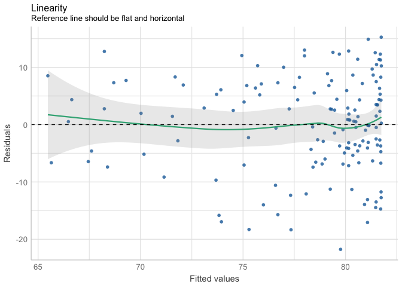

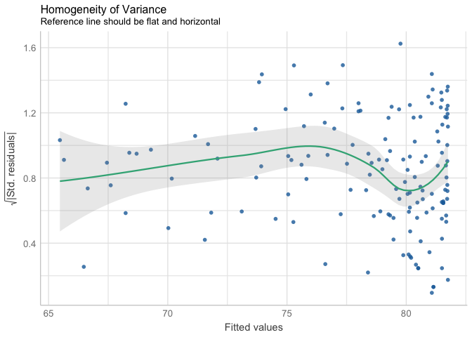

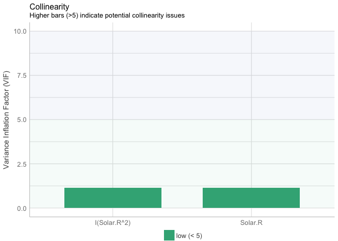

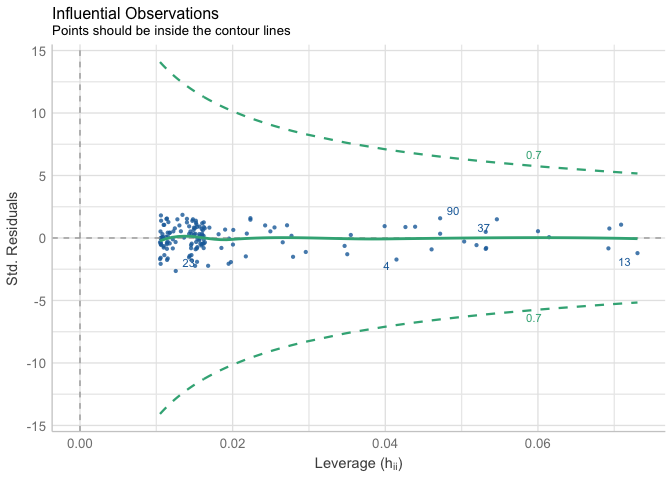

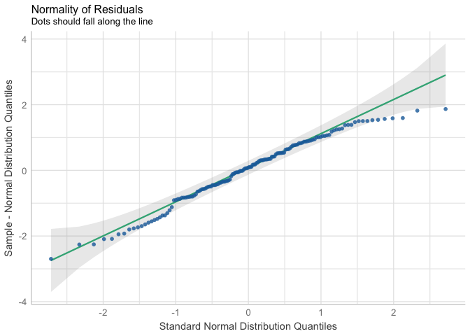

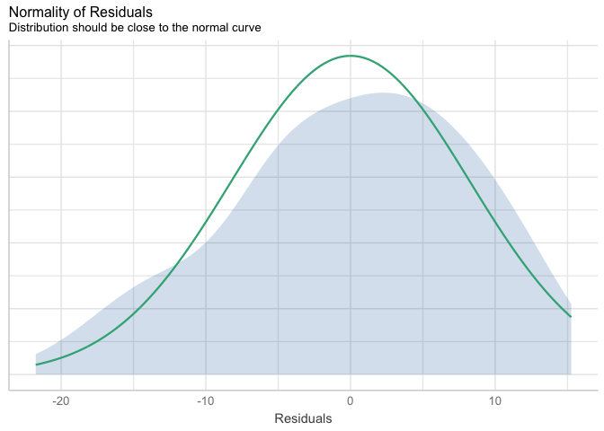

```r
# graficos diagnostico
# plot(mod2)
check_model(mod2,panel=F)
```

### 1.2.3 Compara modelos

```r
TMod(mod1,mod2) # DescTools
```

```
##             coef      mod1         mod2
## 1    (Intercept)    72.863 ***   64.268 ***
## 2        Solar.R     0.028 ***    0.176 ***
## 3   I(Solar.R^2)     -           -0.000 ***
## 4            ---
## 5      r.squared     0.076        0.203
## 6  adj.r.squared     0.070        0.192
## 7          sigma     8.898        8.294
## 8         logLik  -525.283     -514.524
## 9       deviance 11400.171     9838.020
## 10           AIC  1056.565     1037.049
## 11           BIC  1065.516     1048.983
## 12         numdf     1            2
## 13         dendf   144          143
## 14             N   146          146
## 15        n vars     1            2
## 16        n coef     2            3
## 17             F    11.859       18.177
## 18             p     0.001        9.254e-08
## 19           MAE     7.060        6.730
## 20          MAPE     0.094        0.090
## 21           MSE    78.083       67.384
## 22          RMSE     8.836        8.209
```

```r
modelsummary::modelsummary(list(Lineal=mod1,Cuadratico=mod2),
                           statistic = 'conf.int',
                           stars = T)
```

|  | Lineal | Cuadratico |
| --- | --- | --- |
| (Intercept) | 72.863*** | 64.268*** |
|  | [69.515, 76.211] | [59.529, 69.007] |
| Solar.R | 0.028*** | 0.176*** |
|  | [0.012, 0.044] | [0.113, 0.239] |
| I(Solar.R^2) |  | 0.000*** |
|  |  | [-0.001, 0.000] |
| Num.Obs. | 146 | 146 |
| R2 | 0.076 | 0.203 |
| R2 Adj. | 0.070 | 0.192 |
| AIC | 1056.6 | 1037.0 |
| BIC | 1065.5 | 1049.0 |
| Log.Lik. | -525.283 | -514.524 |
| F | 11.859 | 18.177 |

* p < 0.1, ** p < 0.05, *** p < 0.01

```r
sjPlot::tab_model(mod1,mod2,
                  title = 'Comparasion de modelos',
                  collapse.ci = T,
                  ci.hyphen = ' , ',
                  show.stat = T,
                  dv.labels = c('Lineal','Cuadrático'),
                  digits = 3)
```

Comparasion de modelos

|  | Lineal |  |  | Cuadrático |  |  |
| --- | --- | --- | --- | --- | --- | --- |
| Predictors | Estimates | Statistic | p | Estimates | Statistic | p |
| (Intercept) | 72.863 (69.515 , 76.211) | 43.014 | **<0.001** | 64.268 (59.529 , 69.007) | 26.808 | **<0.001** |
| Solar.R | 0.028 (0.012 , 0.044) | 3.444 | **0.001** | 0.176 (0.113 , 0.239) | 5.512 | **<0.001** |
| Solar.R^2 |  |  |  | -0.000 (-0.001 , -0.000) | -4.765 | **<0.001** |
| Observations | 146 |  |  | 146 |  |  |
| R<sup>2</sup> / R<sup>2</sup> adjusted | 0.076 / 0.070 |  |  | 0.203 / 0.192 |  |  |

```r
comp.mods = compare_performance(mod1,mod2,rank = T) # performance
comp.mods
```

| Name | Model | AIC | BIC | R2 | R2_adjusted | RMSE | Sigma | Performance_Score |
| --- | --- | --- | --- | --- | --- | --- | --- | --- |
| mod2 | lm | 1037.049 | 1048.983 | 0.20269032 | 0.1915391 | 8.208758 | 8.294417 | 1 |
| mod1 | lm | 1056.565 | 1065.516 | 0.07608786 | 0.0696718 | 8.836479 | 8.897632 | 0 |

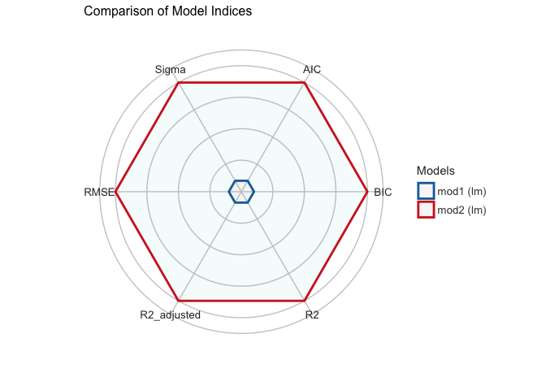

```r
plot(comp.mods)
```

### 1.2.4 Graficos

Para agregar lineas de tendencia en *ggplot2* se usa la funcion `geom_smooth`. Por defecto ajusta una curva loess, pero para cambiarlo se usa `method = 'lm'`, y para especificar una ecuacion diferente a la regresion simple se usa `formula`, donde `y` y `x` son genericos, **NO** hay que poner el nombre de las variables que se esta graficando.

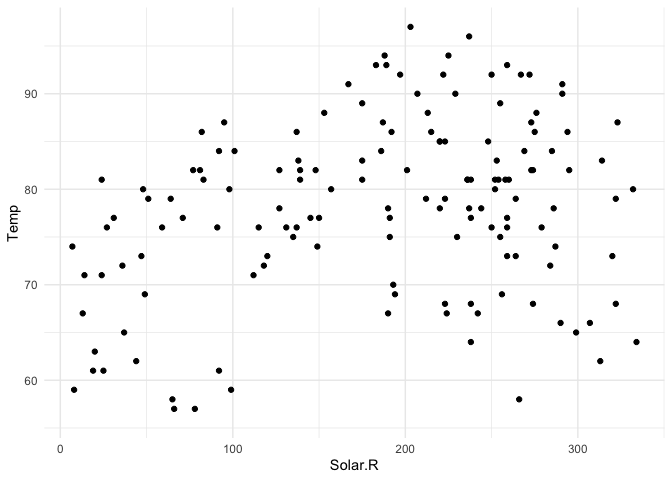

```r
ggplot(airq, aes(Solar.R,Temp)) +
  geom_point()
```

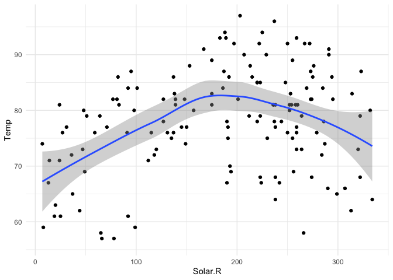

```r
ggplot(airq, aes(Solar.R,Temp)) +
  geom_point() +
  geom_smooth()
```

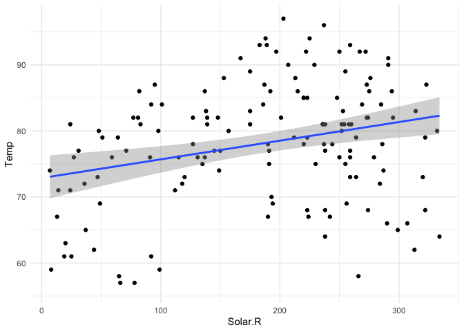

```r
# grafico regresion lineal
ggplot(airq, aes(Solar.R,Temp)) +
  geom_point() +
  geom_smooth(method = 'lm')
```

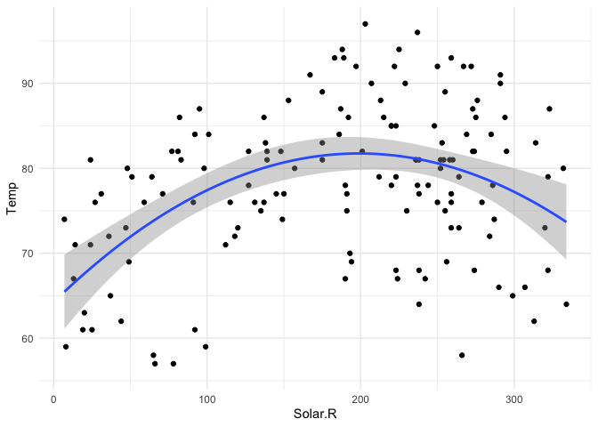

```r
# grafico regresion cuadratica
ggplot(airq, aes(Solar.R,Temp)) +
  geom_point() +
  geom_smooth(method = 'lm', formula = y~poly(x, 2))
```

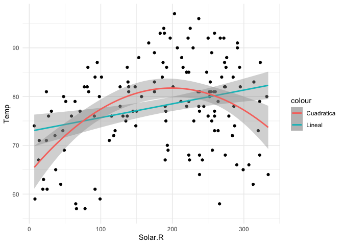

```r
# grafico regresion lineal y cuadratica
ggplot(airq, aes(Solar.R,Temp)) +
  geom_point() +
  geom_smooth(method = 'lm', aes(col='Lineal')) +
  geom_smooth(method = 'lm', formula = y~poly(x, 2), aes(col='Cuadratica'))
```

# 2 Probabilidad

```r
A = matrix(data = c(15,24,23,14,11,13),nrow = 2)
colnames(A) = c('A','B','C')
row.names(A) = c('X','Y')
PercTable(A)
```

```
##
##              A     B     C
##
## X   freq    15    23    11
##     perc 15.0% 23.0% 11.0%
##
## Y   freq    24    14    13
##     perc 24.0% 14.0% 13.0%
##
```

```r
PercTable(A, margins = c(1,2))
```

```
##
##                 A      B      C    Sum
##
## X     freq     15     23     11     49
##       perc  15.0%  23.0%  11.0%  49.0%
##
## Y     freq     24     14     13     51
##       perc  24.0%  14.0%  13.0%  51.0%
##
## Sum   freq     39     37     24    100
##       perc  39.0%  37.0%  24.0% 100.0%
##
```